# BRFSS 2013-2017 Survey EDA-BMI

Amanda Kimball

11/19/2020

The Smart: City and county survey data put together by the Center for Disease Control and Prevention: Behavioral risk factor surveillance system (Smart data, 2013-2017). Contains a number of survey response data that is equally distributed across a range of areas referred to as Metropolitan and Micropolitan statistical areas. The survey data covers health indicators, diet choices, health insurance availability, demographics, and economic factors. I initially uploaded the data and pulled out the data related to body mass index and age demographics. I evaluated using 5 years of data in order to increase the number of regions in my analysis. I ended up using only the 2017 analysis becuase adding the 5 years removes important variables high blood pressure and high cholesterol but am saving the analysis for future reference.

```r
library(foreign)
BRFSS2017 <- read.xport("MMSA2017.XPT")
BRFSS2016 <- read.xport("MMSA2016.XPT")
BRFSS2015 <- read.xport("MMSA2015.XPT")
BRFSS2014 <- read.xport("MMSA2014.XPT")
BRFSS2013 <- read.xport("MMSA2013.XPT")
```

I identified the variables needed for the analysis as indicated ‘vars’ below. Then subset each of the imported files by those factors.

```r
#data <- subset(BRFSS2017, select = c(47:49, 122:129, 174, 175, 177))

vars <- c("PREGNANT", "X_BMI5", "X_BMI5CAT", "X_RFBMI5", "X_AGE80", "X_MMSA", "X_MMSAWT", "MMSANAME")

data17 <- subset(BRFSS2017, select = vars)
data16 <- subset(BRFSS2016, select = vars)
data15 <- subset(BRFSS2015, select = vars)
data14 <- subset(BRFSS2014, select = vars)
data13 <- subset(BRFSS2013, select = vars)

data <- rbind(data13, data14, data15, data16, data17)

#data$County <- gsub(", Metropolitan Statistical Area", "", data$County)
#data$County <- gsub(", Micropolitan Statistical Area", "", data$County)
#data$County <- gsub(", Metropolitan Division", "", data$County)
#data$State <- gsub(".*,", "", data$County)
#data$State <- gsub(" ", "", data$State)
#data$County <- gsub(",.*", "", data$County)
str(data)
```

```
## 'data.frame':    1208648 obs. of  8 variables:
##  $ PREGNANT : num  2 NA NA NA NA NA NA NA NA NA ...
##  $ X_BMI5   : num  2103 3023 3212 3067 2441 ...
##  $ X_BMI5CAT: num  2 4 4 4 2 3 2 2 2 3 ...
##  $ X_RFBMI5 : num  1 2 2 2 1 2 1 1 1 2 ...
##  $ X_AGE80  : num  40 75 63 52 70 38 53 49 74 66 ...
##  $ X_MMSA   : num  10380 10380 10380 10380 10380 ...
##  $ X_MMSAWT : num  294.3 89.2 251.1 448.6 60.2 ...
##  $ MMSANAME : Factor w/ 170 levels "Aguadilla-Isabela, PR, Metropolitan Statistical Area",..: 1 1 1 1 1 1 1 1 1 1 ...
```

I am focusing on adults 18 and older for the analysis and will eliminate all younger participants which are not included in the BRFSS data, so I remove the younger participants.

```r
data <- data[(data$X_AGE80 >= 18),]
summary(data$X_AGE80)
```

```
##    Min. 1st Qu.  Median    Mean 3rd Qu.    Max.
##   18.00   42.00   57.00   54.45   68.00   80.00
```

Here are the calculated body mass indicator variables. As shown there are several missing values.

```r
summary(data)
```

```
##     PREGNANT           X_BMI5        X_BMI5CAT        X_RFBMI5
##  Min.   :1         Min.   :1202    Min.   :1.00    Min.   :1.000
##  1st Qu.:2         1st Qu.:2367    1st Qu.:2.00    1st Qu.:1.000
##  Median :2         Median :2663    Median :3.00    Median :2.000
##  Mean   :2         Mean   :2781    Mean   :2.92    Mean   :2.207
##  3rd Qu.:2         3rd Qu.:3072    3rd Qu.:4.00    3rd Qu.:2.000
##  Max.   :9         Max.   :9960    Max.   :4.00    Max.   :9.000
##  NA's   :1010619   NA's   :91861   NA's   :91861
##     X_AGE80          X_MMSA         X_MMSAWT
##  Min.   :18.00   Min.   :10100   Min.   :    0.15
##  1st Qu.:42.00   1st Qu.:19740   1st Qu.:  111.65
##  Median :57.00   Median :34980   Median :  274.50
##  Mean   :54.45   Mean   :31606   Mean   :  648.26
##  3rd Qu.:68.00   3rd Qu.:40380   3rd Qu.:  690.78
##  Max.   :80.00   Max.   :49660   Max.   :43227.53
##
##                                                                    MMSANAME
##  Minneapolis-St. Paul-Bloomington, MN-WI, Metropolitan Statistical Area: 43290
##  Washington-Arlington-Alexandria, DC-VA-MD-WV, Metropolitan Division   : 43019
##  New York-Jersey City-White Plains, NY-NJ, Metropolitan Division       : 41963
##  Providence-Warwick, RI-MA, Metropolitan Statistical Area              : 35906
##  Kansas City, MO-KS, Metropolitan Statistical Area                     : 32192
##  Phoenix-Mesa-Scottsdale, AZ, Metropolitan Statistical Area            : 30456
##  (Other)                                                               :981822
```

There are a significant number of NA’s for the BMI index. I am going to focus on one county’s data to understand the nuances in the data set and then apply what I have learned to the other counties. Albuquerque is in all five data sets. I can safely remove the individuals listed as pregnant as outliers with a cause. It appears that the remaining values are missing the weight or height factor either listed as 9999 (Refused) or 7777 (Not sure).

```r
Albuquerque <- data[data$X_MMSA == 10740,]
summary(Albuquerque)
```

```
##     PREGNANT         X_BMI5       X_BMI5CAT        X_RFBMI5      X_AGE80
##  Min.   :1.000   Min.   :1225   Min.   :1.000   Min.   :1.0   Min.   :18.00
##  1st Qu.:2.000   1st Qu.:2348   1st Qu.:2.000   1st Qu.:1.0   1st Qu.:41.00
##  Median :2.000   Median :2650   Median :3.000   Median :2.0   Median :56.00
##  Mean   :2.012   Mean   :2735   Mean   :2.867   Mean   :2.1   Mean   :53.96
##  3rd Qu.:2.000   3rd Qu.:3011   3rd Qu.:4.000   3rd Qu.:2.0   3rd Qu.:67.00
##  Max.   :9.000   Max.   :8503   Max.   :4.000   Max.   :9.0   Max.   :80.00
##  NA's   :6910    NA's   :530    NA's   :530
##      X_MMSA         X_MMSAWT
##  Min.   :10740   Min.   :   3.099
##  1st Qu.:10740   1st Qu.: 173.541
##  Median :10740   Median : 321.368
##  Mean   :10740   Mean   : 420.603
##  3rd Qu.:10740   3rd Qu.: 553.970
##  Max.   :10740   Max.   :4069.332
##
##                                                              MMSANAME
##  Albuquerque, NM, Metropolitan Statistical Area                  :8290
##  Aguadilla-Isabela, PR, Metropolitan Statistical Area            :   0
##  Akron, OH, Metropolitan Statistical Area                        :   0
##  Allentown-Bethlehem-Easton, PA-NJ, Metropolitan Statistical Area:   0
##  Anchorage, AK, Metropolitan Statistical Area                    :   0
##  Atlanta-Sandy Springs-Roswell, GA, Metropolitan Statistical Area:   0
##  (Other)                                                         :   0
```

I calculated the average for the Albuquerque and compared it with the average for the entire data sample and find that they are within 0.2 kg/m2 difference. The weight factor ‘X_MMSAWT’ is used to adjust for sampling methodology. Note that the documentation indicates a 2 decimal place value in the 4 digit value, so i divide by 100. Based off this analysis, I am going to impute the average for the population as the NAs.

```r
Albuquerqueavg <- mean((Albuquerque$X_BMI5*Albuquerque$X_MMSAWT),na.rm=TRUE)/
  mean(Albuquerque$X_MMSAWT,na.rm=TRUE)
popavg <- mean((data$X_BMI5*data$X_MMSAWT), na.rm=TRUE)/mean(data$X_MMSAWT,na.rm=TRUE)
paste("Average BMI in population is", round(popavg/100, 1), "and average BMI for Albuquerque is",
  round(Albuquerqueavg/100, 1), ".")
```

```
## [1] "Average BMI in population is 27.4 and average BMI for Albuquerque is 27.2 ."
```

```r
data <- subset(data, (PREGNANT != 1) | is.na(PREGNANT))
index <- is.na(data$X_BMI5)
data$X_BMI5[index] <- popavg
data$X_BMI5CAT[index] <- 3
data$X_RFBMI5[index] <- 2
summary(data)
```

```
##     PREGNANT           X_BMI5       X_BMI5CAT        X_RFBMI5
##  Min.   :2         Min.   :1202   Min.   :1.000   Min.   :1.000
##  1st Qu.:2         1st Qu.:2389   1st Qu.:2.000   1st Qu.:1.000
##  Median :2         Median :2734   Median :3.000   Median :2.000
##  Mean   :2         Mean   :2778   Mean   :2.924   Mean   :1.673
##  3rd Qu.:2         3rd Qu.:3030   3rd Qu.:4.000   3rd Qu.:2.000
##  Max.   :9         Max.   :9960   Max.   :4.000   Max.   :2.000
##  NA's   :1010619
##     X_AGE80         X_MMSA         X_MMSAWT
##  Min.   :18.0   Min.   :10100   Min.   :    0.15
##  1st Qu.:42.0   1st Qu.:19740   1st Qu.:  111.24
##  Median :57.0   Median :34980   Median :  273.50
##  Mean   :54.6   Mean   :31604   Mean   :  645.85
##  3rd Qu.:68.0   3rd Qu.:40380   3rd Qu.:  687.73
##  Max.   :80.0   Max.   :49660   Max.   :43227.53
##
##                                                                    MMSANAME
##  Minneapolis-St. Paul-Bloomington, MN-WI, Metropolitan Statistical Area: 42987
##  Washington-Arlington-Alexandria, DC-VA-MD-WV, Metropolitan Division   : 42774
##  New York-Jersey City-White Plains, NY-NJ, Metropolitan Division       : 41583
##  Providence-Warwick, RI-MA, Metropolitan Statistical Area              : 35752
##  Kansas City, MO-KS, Metropolitan Statistical Area                     : 32005
##  Phoenix-Mesa-Scottsdale, AZ, Metropolitan Statistical Area            : 30317
##  (Other)                                                               :976031
```

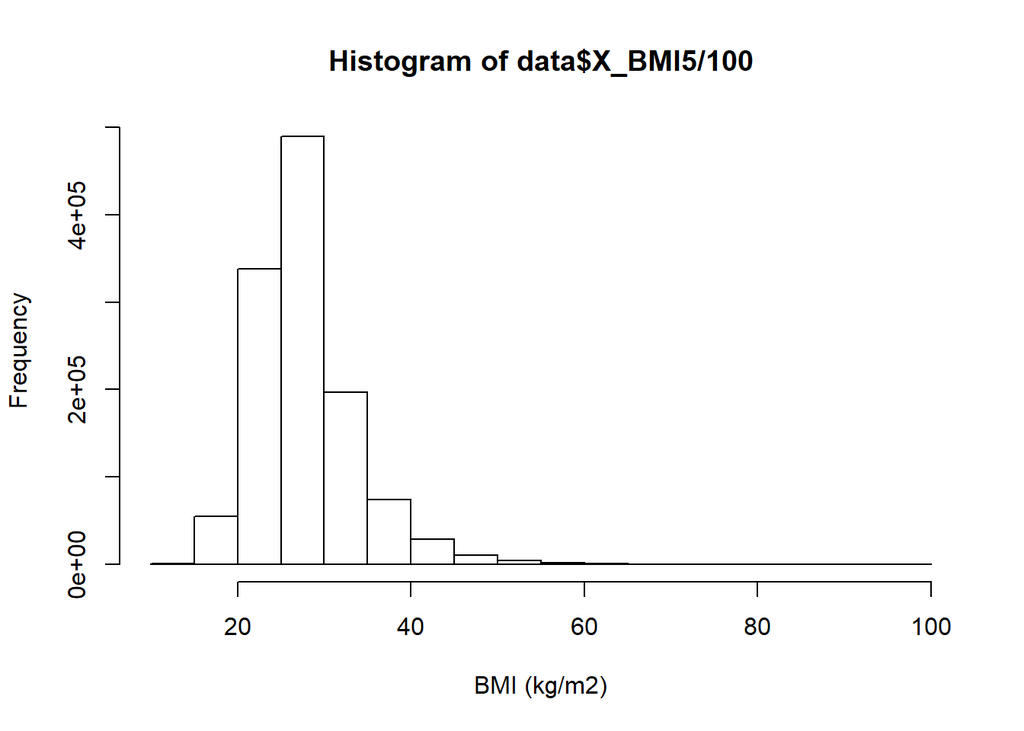

```r
hist(data$X_BMI5/100, xlab = "BMI (kg/m2)", breaks = 20)
```

The distribution of BMI does not correlate with age.

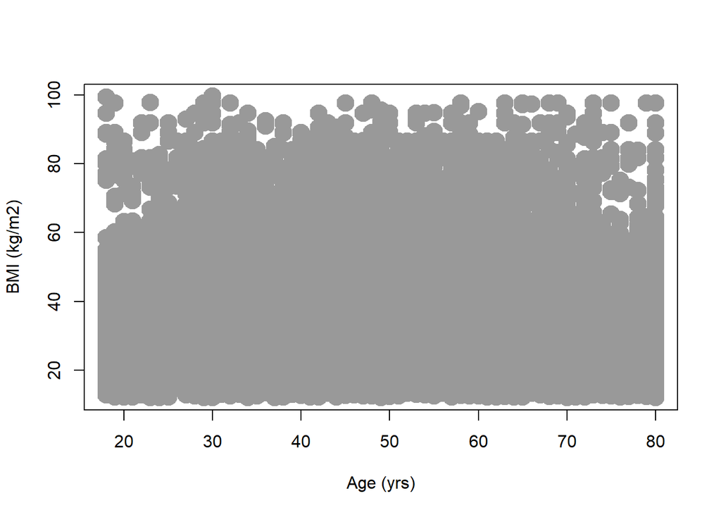

```r
plot(data$X_AGE80, data$X_BMI5/100, ylab = "BMI (kg/m2)", xlab = "Age (yrs)", lwd = 10, col = "grey60")
```

Extreme Obesity is defined as over 40 kg/m2 but was not segregated in the original data set. I will add that level to the data for the visualizations and gives another level of detail towards poor health conditions.

```r
data$X_BMI5CAT[data$X_BMI5 > 4000] <- 5
summary(data)
```

```
##     PREGNANT           X_BMI5       X_BMI5CAT        X_RFBMI5
##  Min.   :2         Min.   :1202   Min.   :1.000   Min.   :1.000
##  1st Qu.:2         1st Qu.:2389   1st Qu.:2.000   1st Qu.:1.000
##  Median :2         Median :2734   Median :3.000   Median :2.000
##  Mean   :2         Mean   :2778   Mean   :2.963   Mean   :1.673
##  3rd Qu.:2         3rd Qu.:3030   3rd Qu.:4.000   3rd Qu.:2.000
##  Max.   :9         Max.   :9960   Max.   :5.000   Max.   :2.000
##  NA's   :1010619
##     X_AGE80         X_MMSA         X_MMSAWT
##  Min.   :18.0   Min.   :10100   Min.   :    0.15
##  1st Qu.:42.0   1st Qu.:19740   1st Qu.:  111.24
##  Median :57.0   Median :34980   Median :  273.50
##  Mean   :54.6   Mean   :31604   Mean   :  645.85
##  3rd Qu.:68.0   3rd Qu.:40380   3rd Qu.:  687.73
##  Max.   :80.0   Max.   :49660   Max.   :43227.53
##
##                                                                    MMSANAME
##  Minneapolis-St. Paul-Bloomington, MN-WI, Metropolitan Statistical Area: 42987
##  Washington-Arlington-Alexandria, DC-VA-MD-WV, Metropolitan Division   : 42774
##  New York-Jersey City-White Plains, NY-NJ, Metropolitan Division       : 41583
##  Providence-Warwick, RI-MA, Metropolitan Statistical Area              : 35752
##  Kansas City, MO-KS, Metropolitan Statistical Area                     : 32005
##  Phoenix-Mesa-Scottsdale, AZ, Metropolitan Statistical Area            : 30317
##  (Other)                                                               :976031
```

I will aggregate the data as an average BMI by county (MMSA Region).

```r
MMSAWT <- aggregate(data$X_MMSAWT~data$X_MMSA, FUN = mean)
MMSABMI <- aggregate(data$X_BMI5*data$X_MMSAWT/100~data$X_MMSA, FUN = mean)
names(MMSABMI) <- c("MMSA", "BMI_(kg/m2)")
MMSABMI$'BMI_(kg/m2)' <- MMSABMI$'BMI_(kg/m2)'/MMSAWT$`data$X_MMSAWT`
summary(MMSABMI)
```

```
##       MMSA        BMI_(kg/m2)
##  Min.   :10100   Min.   :25.94
##  1st Qu.:19450   1st Qu.:27.49
##  Median :30970   Median :27.93
##  Mean   :30098   Mean   :27.88
##  3rd Qu.:40200   3rd Qu.:28.24
##  Max.   :49660   Max.   :29.61
```

```r
data$underweight <- ifelse(data$X_BMI5CAT == 1, 1, 0)
data$normalweight <- ifelse(data$X_BMI5CAT == 2, 1, 0)
data$overweight <- ifelse(data$X_BMI5CAT == 3, 1, 0)
data$obese <- ifelse(data$X_BMI5CAT == 4, 1, 0)
data$extremeobesity <- ifelse(data$X_BMI5CAT == 5, 1, 0)

#Each observation dummy value times it's weight factor.
MMSA_BMI <- data[c("underweight", "normalweight", "overweight", "obese", "extremeobesity")]*data$X_MMSAWT
#Keep MMSA by each observation
MMSA_BMI$MMSA_Name <- data$X_MMSA
#Create total wt_factor for each MMSA
MMSAWT <- aggregate(data$X_MMSAWT~data$X_MMSA, FUN = sum)
names(MMSAWT) <- c("MMSA_NAME", "WT_Factor")
#Aggregate the health indicators by MMSA
MMSA_BMI <- aggregate(.~MMSA_Name, data = MMSA_BMI, FUN = sum)
#Divide out each of the total wt factors.
MMSABMI[3:7] <- MMSA_BMI[2:6]/MMSAWT$WT_Factor
summary(MMSABMI)
```

```
##       MMSA        BMI_(kg/m2)     underweight        normalweight
##  Min.   :10100   Min.   :25.94   Min.   :0.007477   Min.   :0.2342
##  1st Qu.:19450   1st Qu.:27.49   1st Qu.:0.014803   1st Qu.:0.2892
##  Median :30970   Median :27.93   Median :0.016730   Median :0.3065
##  Mean   :30098   Mean   :27.88   Mean   :0.017439   Mean   :0.3095
##  3rd Qu.:40200   3rd Qu.:28.24   3rd Qu.:0.019679   3rd Qu.:0.3285
##  Max.   :49660   Max.   :29.61   Max.   :0.036068   Max.   :0.4393
##    overweight         obese        extremeobesity
##  Min.   :0.3384   Min.   :0.1313   Min.   :0.01793
##  1st Qu.:0.3844   1st Qu.:0.2132   1st Qu.:0.03537
##  Median :0.3964   Median :0.2342   Median :0.04298
##  Mean   :0.3963   Mean   :0.2336   Mean   :0.04324
##  3rd Qu.:0.4094   3rd Qu.:0.2509   3rd Qu.:0.05107
##  Max.   :0.4556   Max.   :0.3593   Max.   :0.07540
```

Check to see if they add up to 100% of values for 1 region: Albuquerque, NM was in all 5 years.

```r
paste("BMI has", sum(MMSABMI[3:7][MMSABMI == 10740,])*100, "% of data.")
```

```
## [1] "BMI has 100 % of data."
```

I export this data so that I can create GEO Map data visualizations of the health indicators in Tableau.

```r
write.csv(MMSABMI, 'healthdata4.csv', row.names = FALSE)
```

References:

Unknown. (2017) Smart: City and county survey data: 2017 Data. Center for Disease Control and Prevention: Behavioral risk factor surveillance system. Retrieved November 1, 2020 from: https://www.cdc.gov/brfss/smart/Smart_data.htm